# Lab3-parte2

Bruna Barbosa

March 1, 2017

### 1.Separe os dados em treino e teste;

```r
library(ISLR)
library(readr)
library(caret)
library(dplyr)
library(reshape2)
library(caret)

set.seed(9560)
#setwd("~/AD2/Lab3-Parte2")
treino_classificacao_v2 <- read_csv("treino_classificacao_v2.csv")

##Reshape nos dados
classificacao.clean <- treino_classificacao_v2 %>%
  filter(!is.na(MAT_MEDIA_FINAL))

classificacao.clean$CREDITOS <- 4

##novo atributo
classificacao.clean[classificacao.clean$MAT_TUR_ANO < 2011, "ENEM"] <- FALSE
classificacao.clean[classificacao.clean$MAT_TUR_ANO >= 2011, "ENEM"] <- TRUE

classificacao.cra <- classificacao.clean %>%
  group_by(MAT_ALU_MATRICULA, EVADIU, ENEM) %>%
  mutate(cra.contrib = MAT_MEDIA_FINAL*CREDITOS) %>%
  summarise(cra = sum(cra.contrib)/sum(CREDITOS))


classificacao.model.input <- classificacao.clean %>%
  group_by(MAT_ALU_MATRICULA,disciplina)  %>%
  filter(MAT_MEDIA_FINAL == max(MAT_MEDIA_FINAL)) %>%
  ungroup() %>%
  select(MAT_ALU_MATRICULA,disciplina,MAT_MEDIA_FINAL) %>%
  mutate(disciplina = as.factor(gsub(" ",".",disciplina))) %>%
  dcast(MAT_ALU_MATRICULA ~ disciplina, mean) %>%
  merge(classificacao.cra)

##Split dos dados
split <- createDataPartition(y=classificacao.model.input$EVADIU, p = 0.90, list = FALSE)
train <- classificacao.model.input[split,]
test <- classificacao.model.input[-split,]

##to factor
train$EVADIU <- as.factor(train$EVADIU)
train$MAT_ALU_MATRICULA <- as.factor(train$MAT_ALU_MATRICULA)
train$ENEM <- as.logical(train$ENEM)

##remove NA's
train.clean <- train %>%
  filter(!is.na(Álgebra.Vetorial.e.Geometria.Analítica)) %>%
  filter(!is.na(Cálculo.Diferencial.e.Integral.I)) %>%
  filter(!is.na(Introdução.à.Computação)) %>%
  filter(!is.na(Laboratório.de.Programação.I)) %>%
  filter(!is.na(Programação.I)) %>%
  filter(!is.na(Leitura.e.Produção.de.Textos))

##remove NA's
test.clean <- test %>%
  filter(!is.na(Álgebra.Vetorial.e.Geometria.Analítica)) %>%
  filter(!is.na(Cálculo.Diferencial.e.Integral.I)) %>%
  filter(!is.na(Introdução.à.Computação)) %>%
  filter(!is.na(Laboratório.de.Programação.I)) %>%
  filter(!is.na(Programação.I)) %>%
  filter(!is.na(Leitura.e.Produção.de.Textos))
```

### 2.Use como atributos as médias das disciplinas mais o atributo que você criou na parte 1;

O atributo que eu escolhi avaliar foi se o aluno teve como metodo de entrada o enem.

### 3.Treine modelos de regressão logística;

```r
##Modelo com todas as disciplinas
model <- glm(EVADIU ~ Cálculo.Diferencial.e.Integral.I
             + Introdução.à.Computação
             + Laboratório.de.Programação.I
             + Leitura.e.Produção.de.Textos
             + Programação.I
             + Álgebra.Vetorial.e.Geometria.Analítica
             ,family=binomial, data=train.clean)

summary(model)
```

```
##
## Call:
## glm(formula = EVADIU ~ Cálculo.Diferencial.e.Integral.I + Introdução.à.Computação +
##     Laboratório.de.Programação.I + Leitura.e.Produção.de.Textos +
##     Programação.I + Álgebra.Vetorial.e.Geometria.Analítica, family = binomial,
##     data = train.clean)
##
## Deviance Residuals:
##     Min       1Q   Median       3Q      Max
## -1.4452  -0.1740  -0.1305  -0.1010   3.2559
##
## Coefficients:
##                                        Estimate Std. Error z value
## (Intercept)                              0.5837     0.4066   1.436
## Cálculo.Diferencial.e.Integral.I        -0.2302     0.1374  -1.675
## Introdução.à.Computação                 -0.4892     0.1661  -2.946
## Laboratório.de.Programação.I            -0.2391     0.2675  -0.894
## Leitura.e.Produção.de.Textos            -0.1828     0.1072  -1.705
## Programação.I                            0.2671     0.2960   0.902
## Álgebra.Vetorial.e.Geometria.Analítica   0.1909     0.1377   1.386
##                                        Pr(>|z|)
## (Intercept)                             0.15111
## Cálculo.Diferencial.e.Integral.I        0.09390 .
## Introdução.à.Computação                 0.00322 **
## Laboratório.de.Programação.I            0.37138
## Leitura.e.Produção.de.Textos            0.08814 .
## Programação.I                           0.36695
## Álgebra.Vetorial.e.Geometria.Analítica  0.16565
## ---
## Signif. codes:  0 '***' 0.001 '**' 0.01 '*' 0.05 '.' 0.1 ' ' 1
##
## (Dispersion parameter for binomial family taken to be 1)
##
##     Null deviance: 270.80  on 914  degrees of freedom
## Residual deviance: 164.59  on 908  degrees of freedom
## AIC: 178.59
##
## Number of Fisher Scoring iterations: 7
```

```r
##Modelo não balanceado
table(train$EVADIU)
```

```
##
## FALSE  TRUE
##  1091    81
```

```r
##Modelo com todas as disciplinas + ENEM
model.enem <- glm(EVADIU ~ Cálculo.Diferencial.e.Integral.I
                  + Introdução.à.Computação
                  + Laboratório.de.Programação.I
                  + Leitura.e.Produção.de.Textos
                  + Programação.I
                  + Álgebra.Vetorial.e.Geometria.Analítica + ENEM
                  ,family=binomial, data=train.clean)

##Modelo não balanceado
table(train$EVADIU)
```

```
##
## FALSE  TRUE
##  1091    81
```

> Modelos de regressão logistica balanceados

No proximo modelo foram criadas mais instancias da classe dos alunos que evadiram

```r
library(ROSE)
library(pROC)
#oversampling
up_train <- upSample(x = train.clean[, -ncol(train.clean)],
                     y = train.clean$EVADIU)
table(up_train$EVADIU)
```

```
##
## FALSE  TRUE
##   884   884
```

```r
##modelo com balanceamento
model.up <- glm(EVADIU ~ Cálculo.Diferencial.e.Integral.I
                + Introdução.à.Computação
                + Laboratório.de.Programação.I
                + Leitura.e.Produção.de.Textos
                + Programação.I
                + Álgebra.Vetorial.e.Geometria.Analítica
                ,family=binomial, data=up_train)
```

No proximo modelo foram retiradas instancias da classe dos alunos que não evadiram

```r
set.seed(9560)
down_train <- downSample(x = train.clean[, -ncol(train.clean)],
                         y = train.clean$EVADIU)
table(down_train$Class)
```

```
##
## FALSE  TRUE
##    31    31
```

```r
##modelo com balanceamento
model.down <- glm(EVADIU ~ Cálculo.Diferencial.e.Integral.I
                  + Introdução.à.Computação
                  + Laboratório.de.Programação.I
                  + Leitura.e.Produção.de.Textos
                  + Programação.I
                  + Álgebra.Vetorial.e.Geometria.Analítica
                  ,family=binomial, data=down_train)
```

No proximo modelo utilizei o package ROSE para balancear as classes

```r
#ROSE
set.seed(9560)
rose_train <- ROSE(EVADIU ~ Cálculo.Diferencial.e.Integral.I
                  + Introdução.à.Computação
                  + Laboratório.de.Programação.I
                  + Leitura.e.Produção.de.Textos
                  + Programação.I
                  + Álgebra.Vetorial.e.Geometria.Analítica
                  , data  = train.clean)$data
table(rose_train$EVADIU)
```

```
##
## FALSE  TRUE
##   450   465
```

```r
model.rose <- glm(EVADIU ~ Cálculo.Diferencial.e.Integral.I
                  + Introdução.à.Computação
                  + Laboratório.de.Programação.I
                  + Leitura.e.Produção.de.Textos
                  + Programação.I
                  + Álgebra.Vetorial.e.Geometria.Analítica
                  ,family=binomial, data=rose_train)
```

### 4.Treine modelos de árvore de decisão;

```r
library(rpart)
library(rattle)
```

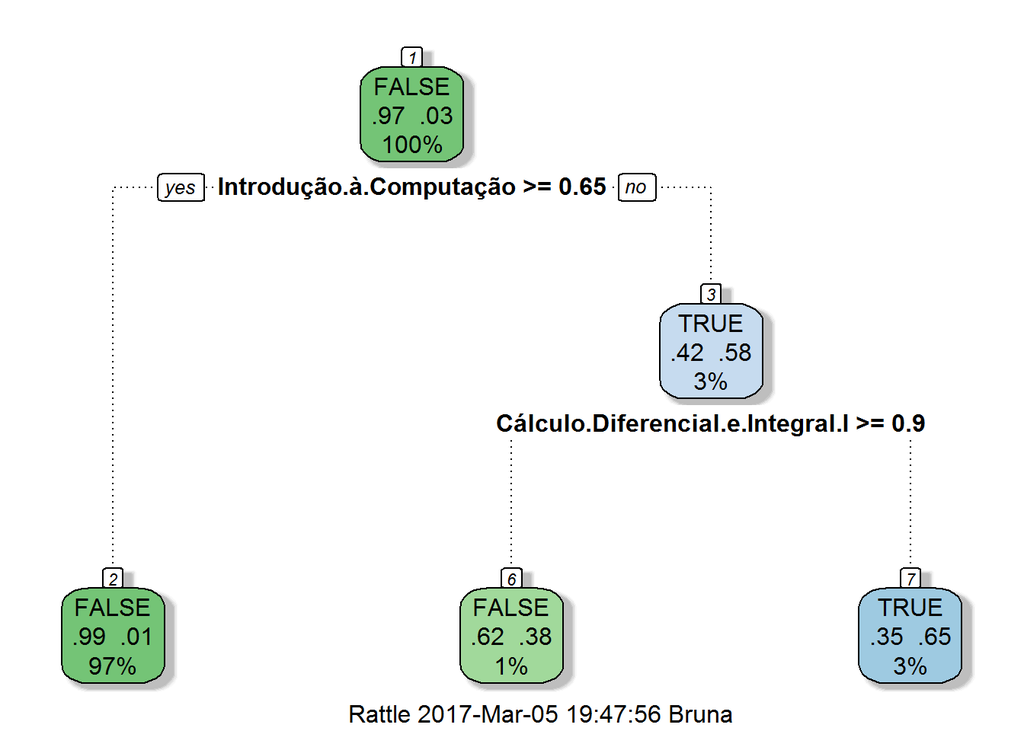

```r
library(rpart.plot)
library(RColorBrewer)

##modelo sem balanceamento
##Parametros de prunning default
fit <- rpart(EVADIU ~ Cálculo.Diferencial.e.Integral.I
             + Introdução.à.Computação
             + Laboratório.de.Programação.I
             + Leitura.e.Produção.de.Textos
             + Programação.I
             + Álgebra.Vetorial.e.Geometria.Analítica,
             data=train.clean,
             method="class")

fancyRpartPlot(fit)
```

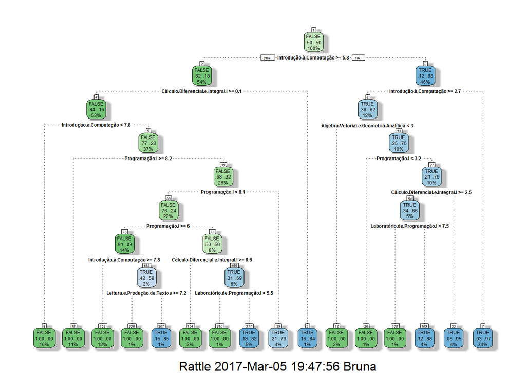

```r
##modelo com balanceamento - oversampling
##Parametros de prunning default
fit.up <- rpart(EVADIU ~ Cálculo.Diferencial.e.Integral.I
             + Introdução.à.Computação
             + Laboratório.de.Programação.I
             + Leitura.e.Produção.de.Textos
             + Programação.I
             + Álgebra.Vetorial.e.Geometria.Analítica,
             data=up_train,
             method="class")

fancyRpartPlot(fit.up)
```

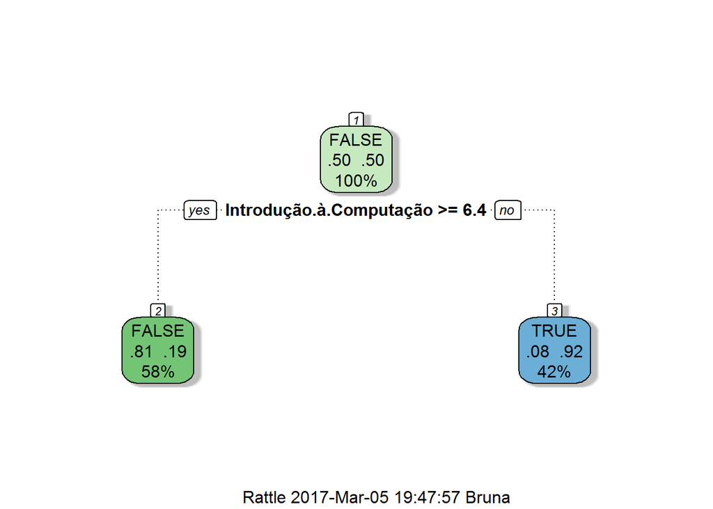

```r
##modelo com balanceamento - undersampling
##Parametros de prunning default
fit.down <- rpart(EVADIU ~ Cálculo.Diferencial.e.Integral.I
             + Introdução.à.Computação
             + Laboratório.de.Programação.I
             + Leitura.e.Produção.de.Textos
             + Programação.I
             + Álgebra.Vetorial.e.Geometria.Analítica,
             data=down_train,
             method="class")

fancyRpartPlot(fit.down)
```

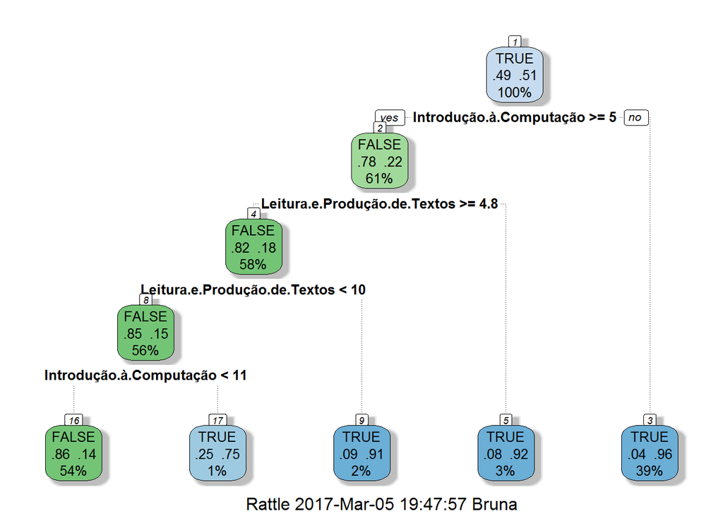

```r
##modelo com balanceamento - ROSE package
##Parametros de prunning default
fit.rose <- rpart(EVADIU ~ Cálculo.Diferencial.e.Integral.I
             + Introdução.à.Computação
             + Laboratório.de.Programação.I
             + Leitura.e.Produção.de.Textos
             + Programação.I
             + Álgebra.Vetorial.e.Geometria.Analítica,
             data=rose_train,
             method="class")

fancyRpartPlot(fit.rose)
```

```r
importancia <- varImp(model, scale = FALSE)
importancia
```

```
##                                          Overall
## Cálculo.Diferencial.e.Integral.I       1.6751590
## Introdução.à.Computação                2.9459793
## Laboratório.de.Programação.I           0.8938880
## Leitura.e.Produção.de.Textos           1.7052697
## Programação.I                          0.9021963
## Álgebra.Vetorial.e.Geometria.Analítica 1.3863107
```

O atributo mais importante para a regressão logistica com todas as disciplinas são 1. Introdução.à.Computação [2.9459793] 2. Leitura.e.Produção.de.Textos [1.7052697]

### 6.Reporte acurácia, precision e recall no treino e teste.

Como você avalia os resultados? Justifique sua resposta.

```r
#Acuracia treino para a regressao logistica
# MEASURING THE PREDICTIVE ABILITY OF THE MODEL
fitted.results <- predict(model,newdata=train.clean,type='response')
fitted.results <- ifelse(fitted.results > 0.5,1,0)
misClasificError <- mean(fitted.results != train.clean$EVADIU)
print(paste('Accuracy',1-misClasificError))
```

```
## [1] "Accuracy 0"
```

```r
accuracy.meas(train.clean$EVADIU, fitted.results)
```

```
##
## Call:
## accuracy.meas(response = train.clean$EVADIU, predicted = fitted.results)
##
## Examples are labelled as positive when predicted is greater than 0.5
##
## precision: 0.727
## recall: 0.516
## F: 0.302
```

```r
#Acuracia teste para a regressao logistica
# MEASURING THE PREDICTIVE ABILITY OF THE MODEL
fitted.results <- predict(model,newdata=test.clean,type='response')
fitted.results <- ifelse(fitted.results > 0.5,1,0)
misClasificError <- mean(fitted.results != test.clean$EVADIU)
print(paste('Accuracy',1-misClasificError))
```

```
## [1] "Accuracy 0.989583333333333"
```

```r
accuracy.meas(test.clean$EVADIU, fitted.results)
```

```
##
## Call:
## accuracy.meas(response = test.clean$EVADIU, predicted = fitted.results)
##
## Examples are labelled as positive when predicted is greater than 0.5
##
## precision: 1.000
## recall: 0.667
## F: 0.400
```

### 7. Controle overfitting usando validação-cruzada (ridge e lasso na regressão logística e condições de “early stopping” nas árvores de decisão, por exemplo, profundidade da árvore);

```r
#Acuracia teste para a regressao logistica com validacao-cruzada
library(caret)


fitControl <- trainControl(method = "cv",
                           number = 10)
# Set seq of lambda to test
lambdaGrid <- expand.grid(lambda = 10^seq(10, -2, length=100))

glmfit <- train(EVADIU ~ Cálculo.Diferencial.e.Integral.I
                + Introdução.à.Computação
                + Laboratório.de.Programação.I
                + Leitura.e.Produção.de.Textos
                + Programação.I
                + Álgebra.Vetorial.e.Geometria.Analítica,
                data = train.clean,
                method='glm',
                trControl = fitControl,
                preProc=c('scale', 'center'))
glmfit
```

```
## Generalized Linear Model
##
## 915 samples
##   6 predictor
##   2 classes: 'FALSE', 'TRUE'
##
## Pre-processing: scaled (6), centered (6)
## Resampling: Cross-Validated (10 fold)
## Summary of sample sizes: 824, 824, 823, 823, 824, 824, ...
## Resampling results:
##
##   Accuracy   Kappa
##   0.9738055  0.56097
##
##
```

```r
coef(glmfit$finalModel)
```

```
##                            (Intercept)
##                             -4.4665378
##       Cálculo.Diferencial.e.Integral.I
##                             -0.5934542
##                Introdução.à.Computação
##                             -0.9297536
##           Laboratório.de.Programação.I
##                             -0.5540254
##           Leitura.e.Produção.de.Textos
##                             -0.3071292
##                          Programação.I
##                              0.6235647
## Álgebra.Vetorial.e.Geometria.Analítica
##                              0.4579898
```

```r
glmfit.pred <- predict(glmfit, test.clean)
```

```r
#Decision tree com atributos de pruning alterados (cp e minsplit)
fitprune <- rpart(EVADIU ~ Cálculo.Diferencial.e.Integral.I
              + Introdução.à.Computação
              + Laboratório.de.Programação.I
              + Leitura.e.Produção.de.Textos
              + Programação.I
              + Álgebra.Vetorial.e.Geometria.Analítica,
              data=train.clean,
              method="class",
              control=rpart.control(minsplit=20, cp=0.02))

Prediction.fit2 <- predict(fitprune, test.clean, type = "class")
accuracy.meas(test.clean$EVADIU,Prediction.fit2)
```

```
##
## Call:
## accuracy.meas(response = test.clean$EVADIU, predicted = Prediction.fit2)
##
## Examples are labelled as positive when predicted is greater than 0.5
##
## precision: 0.031
## recall: 1.000
## F: 0.030
```

### 8. Reporte acurácia, precision e recall da validação-cruzada e teste (para os melhores modelos);

A metrica que escolhi para obter o melhor modelo é a curva ROC (Receiver Operating Characteristics) para medir a acuracia das predicoes nos dados de teste. A curva ROC é formada pelo plot da TP rate (Sensitivity) e FP rate (Specificity).

```r
fitted.results <- predict(model,newdata=test.clean,type='response')
fitted.results <- ifelse(fitted.results > 0.5,1,0)

fitted.results.attr <- predict(model.enem,newdata=test.clean,type='response')
fitted.results.attr <- ifelse(fitted.results.attr > 0.5,1,0)

#oversampling
fitted.results.up <- predict(model.up,newdata=test.clean,type='response')
fitted.results.up <- ifelse(fitted.results.up > 0.5,1,0)

#undersampling
fitted.results.under <- predict(model.down,newdata=test.clean,type='response')
fitted.results.under <- ifelse(fitted.results.under > 0.5,1,0)

#ROSE
fitted.results.rose <- predict(model.rose,newdata=test.clean,type='response')
fitted.results.rose <- ifelse(fitted.results.rose > 0.5,1,0)

##decision tree nao balanceada
fitted.results.dt <- predict(fit, newdata=test.clean, type = "class")

##decision tree balanceada
#oversampling
fitted.results.dt.up <- predict(fit.up,newdata=test.clean, type = "class")

#undersampling
fitted.results.dt.under <- predict(fit.down,newdata=test.clean, type = "class")

#ROSE
fitted.results.dt.rose <- predict(fit.rose,newdata=test.clean, type = "class")

#AUC ROSE
##regressao logistica
roc.curve(test.clean$EVADIU, fitted.results, plotit = F)
```

```
## Area under the curve (AUC): 0.833
```

```r
roc.curve(test.clean$EVADIU, fitted.results.attr, plotit = F)
```

```
## Area under the curve (AUC): 0.833
```

```r
roc.curve(test.clean$EVADIU, fitted.results.up, plotit = F)
```

```
## Area under the curve (AUC): 0.806
```

```r
roc.curve(test.clean$EVADIU, fitted.results.under, plotit = F)
```

```
## Area under the curve (AUC): 0.866
```

```r
roc.curve(test.clean$EVADIU, fitted.results.rose, plotit = F)
```

```
## Area under the curve (AUC): 0.801
```

```r
#arvore de decisao
roc.curve(test.clean$EVADIU, fitted.results.dt, plotit = F)
```

```
## Area under the curve (AUC): 0.833
```

```r
roc.curve(test.clean$EVADIU, fitted.results.dt.up, plotit = F)
```

```
## Area under the curve (AUC): 0.812
```

```r
roc.curve(test.clean$EVADIU, fitted.results.dt.under, plotit = F)
```

```
## Area under the curve (AUC): 0.774
```

```r
roc.curve(test.clean$EVADIU, fitted.results.dt.rose, plotit = F)
```

```
## Area under the curve (AUC): 0.817
```

```r
roc.curve(test.clean$EVADIU,glmfit.pred, plotit = F)
```

```
## Area under the curve (AUC): 0.833
```

```r
roc.curve(test.clean$EVADIU,Prediction.fit2, plotit = F)
```

```
## Area under the curve (AUC): 0.833
```

### 9. Aplique o melhor modelo a você mesmo(a) usando seu histórico e reporte a predição e resultado.

O melhor modelo de acordo com a metrica escolhida (curva ROC) é a regressao logistica balanceada com o metodo de undersampling.

```r
newdata = data.frame(Cálculo.Diferencial.e.Integral.I = 5.7,
                       Introdução.à.Computação = 8.2,
                       Laboratório.de.Programação.I = 8.7,
                       Leitura.e.Produção.de.Textos = 7.8,
                       Programação.I = 8.7,
                       Álgebra.Vetorial.e.Geometria.Analítica = 5.9)

#Com todas as variaveis
result <- predict(model.down, newdata)
result <- ifelse(result > 0.5,'TRUE','FALSE')
result
```

```
##       1
## "FALSE"
```

A predição do melhor modelo mostrou que de acordo com as notas do meu primeiro periodo eu nao irei evadir o curso.